# Test 2_Airline data-Copy1

###### 3. Plot the ACF for each time series data set. Looking at ACF, does it look like there may be a trend or non-constant mean for each time series?

```
Observations: 93
Training Observations: 46
Testing Observations: 47
```

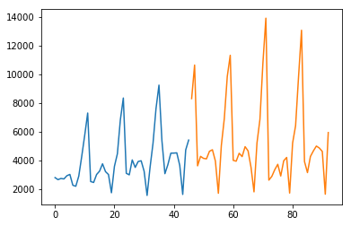

```python
X = series.values
train_size = int(len(X) * 0.50)
train, test = X[0:train_size], X[train_size:len(X)]
print('Observations: %d' % (len(X)))
print('Training Observations: %d' % (len(train)))
print('Testing Observations: %d' % (len(test)))
pyplot.plot(train)
pyplot.plot([None for i in train] + [x for x in test])
pyplot.show()
```

```
1964-01-31    2815
1964-02-29    2672
1964-03-31    2755
1964-04-30    2721
1964-05-31    2946
Freq: M, dtype: int64
```

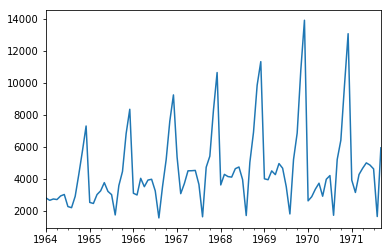

```python
# calculate and plot monthly average
from pandas import Series
from matplotlib import pyplot
# create a boxplot of monthly data
from pandas import Series
from pandas import DataFrame
from pandas import TimeGrouper
from matplotlib import pyplot
from pandas import concat
resample = series.resample('M')
monthly_mean = resample.mean()
print(monthly_mean.head())
monthly_mean.plot()
pyplot.show()
```

```python
### ACF plot for each time series data set.
```

We would expect the ACF for the AR(k) time series to be strong to a lag of k and the inertia of that relationship would carry on to subsequent lag values, trailing off at some point as the effect was weakened

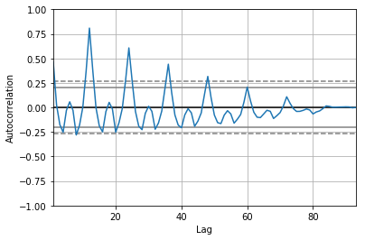

```python
from pandas.tools.plotting import autocorrelation_plot
autocorrelation_plot(series)
pyplot.show()
```

ACF captures the relationship of an observation with past observations in the same and opposite seasons or times of year.

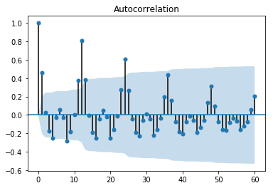

```python
# autocorrelation plot of time series
from pandas import Series
from matplotlib import pyplot
from statsmodels.graphics.tsaplots import plot_acf
plot_acf(series, lags=60)
pyplot.show()
```

###### 4. Now let’s examine each time series data set using unit root tests. First use the KPSS test for each time series data set and tell me if the test suggests if there is a constant mean or not. Then see if you can confirm your KPSS evaluation using the Augmented Dickey Fuller test for each time series. Tell me what you find for each data set.

Kwiatkowski-Philips-Schmidt-Shin (KPSS) test Here accepting null hypothesis means that the series is stationary, and small p-value suggest that the series is NOT stationary and a differencing may be required

###### KPSS output using R

I have used R for KPSS test as it is not available in Python

Code and output for kpss test

kpss_test1 <- kpss.test(df[ ,2], null="Level") kpss_test1

KPSS Test for Level Stationarity

data: df[, 2] KPSS Level = 1.9367, Truncation lag parameter = 13, p-value = 0.01

> kpss_test2 <- kpss.test(df[ ,2], null="Trend")

Warning message: In kpss.test(df[, 2], null = "Trend") : p-value smaller than printed p-value

> kpss_test2

```
KPSS Test for Trend Stationarity
```

data: df[, 2] KPSS Trend = 0.80825, Truncation lag parameter = 13, p-value = 0.01

### Augemented Dickey Fuller Test

The Augmented Dickey-Fuller test is the most common unit root test used. It is a regression of the first difference of the variable on its lagged level as well as additional lags of the first difference. The null is that the series contains a unit root, and the alternative is that the series is stationary.

By default, the number of lags is selected by minimizing the AIC across a range of lag lengths (which can be set using max_lag when initializing the model). Additionally, the basic test includes a constant in the ADF regression.

Null Hypothesis (H0): If accepted, it suggests the time series has a unit root, meaning it is non-stationary. It has some time dependent structure.

Alternate Hypothesis (H1): The null hypothesis is rejected; it suggests the time series does not have a unit root, meaning it is stationary. It does not have time-dependent structure.

```python
from statsmodels.tsa.stattools import adfuller
X = series.values
result = adfuller(X)
print('Results of Dickey-Fuller Test:')
print('ADF Statistic: %f' % result[0])
print('p-value: %f' % result[1])
print('Critical Values:')
for key, value in result[4].items():
    print('\t%s: %.3f' % (key, value))
```

```
Results of Dickey-Fuller Test:
ADF Statistic: -1.445970
p-value: 0.560050
Critical Values:
	1%: -3.514
	5%: -2.898
	10%: -2.586
```

#### PACF

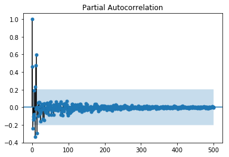

```python
from statsmodels.graphics.tsaplots import plot_pacf
plot_pacf(series, lags=500)
pyplot.show()
```

PACF only describes the direct relationship between an observation and its lag. This would suggest that there would be no correlation for lag values beyond k.

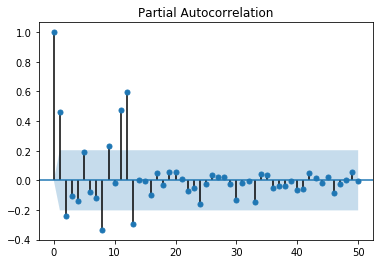

```python
from statsmodels.graphics.tsaplots import plot_pacf
plot_pacf(series, lags=50)
pyplot.show()
```

###### 5. Review the decisions in step # 4. If the test suggests that there is a non-constant mean then use differencing to create a new differenced variable for that time series data set.

a. Plot out the data for the new differenced data set(s). Tell me if it looks like the differencing got rid of the trend or non-constant mean. b. Plot the ACF for the differenced time serie(s). Tell me if this new ACF plot looks like there now is no trend.

```
ADF Statistic: -7.134898
p-value: 0.000000
Critical Values:
	1%: -3.515
	5%: -2.898
	10%: -2.586
```

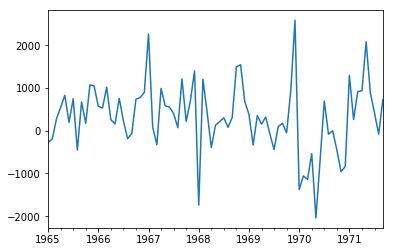

```python
# create and summarize stationary version of time series
from pandas import Series
from statsmodels.tsa.stattools import adfuller
from matplotlib import pyplot

# create a differenced series
def difference(dataset, interval=1):
	diff = list()
	for i in range(interval, len(dataset)):
		value = dataset[i] - dataset[i - interval]
		diff.append(value)
	return Series(diff)

series = Series.from_csv('dataset.csv')
X = series.values
X = X.astype('float32')
# difference data
months_in_year = 12
stationary = difference(X, months_in_year)
stationary.index = series.index[months_in_year:]
# check if stationary
result = adfuller(stationary)
print('ADF Statistic: %f' % result[0])
print('p-value: %f' % result[1])
print('Critical Values:')
for key, value in result[4].items():
	print('\t%s: %.3f' % (key, value))
# save
stationary.to_csv('stationary.csv')
# plot
stationary.plot()
pyplot.show()
```

Yes, based on differencing plot we observe that series has constant mean and variance as compared to without differencing

The results show that the test statistic value -7.134898 is smaller than the critical value at 1% of -3.515. This suggests that we can reject the null hypothesis with a signicance level of less than 1% . Rejecting the null hypothesis means that the process has no unit root, and in turn that the time series is stationary or does not have time-dependent structure.

```python
# invert differenced value
def inverse_difference(history, yhat, interval=1):
    return yhat + history[-interval]
```

##### Plots for insights into how to set the p and q variables for the ARIMA model.

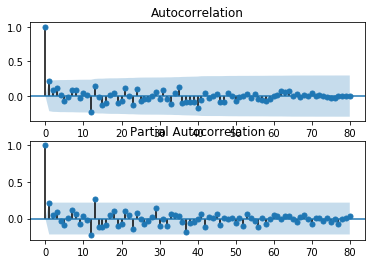

```python
# ACF and PACF plots of time series
from pandas import Series
from statsmodels.graphics.tsaplots import plot_acf
from statsmodels.graphics.tsaplots import plot_pacf
from matplotlib import pyplot
series = Series.from_csv('stationary.csv')
pyplot.figure()
pyplot.subplot(211)
plot_acf(series, ax=pyplot.gca())
pyplot.subplot(212)
plot_pacf(series, ax=pyplot.gca())
pyplot.show()
```

The ACF shows a significant lag for 1 month. The PACF shows a signifcant lag for 1 month, with perhaps some significant lag at 12 and 13 months. Both the ACF and PACF show a drop-off at the same point, perhaps suggesting a mix of AR and MA.

```python
# evaluate manually configured ARIMA model
from pandas import Series
from sklearn.metrics import mean_squared_error
from statsmodels.tsa.arima_model import ARIMA
from math import sqrt

# create a differenced series
def difference(dataset, interval=1):
	diff = list()
	for i in range(interval, len(dataset)):
		value = dataset[i] - dataset[i - interval]
		diff.append(value)
	return diff

# invert differenced value
def inverse_difference(history, yhat, interval=1):
	return yhat + history[-interval]

# load data
series = Series.from_csv('dataset.csv')
# prepare data
X = series.values
X = X.astype('float32')
train_size = int(len(X) * 0.50)
train, test = X[0:train_size], X[train_size:]
# walk-forward validation
history = [x for x in train]
predictions = list()
for i in range(len(test)):
	# difference data
	months_in_year = 12
	diff = difference(history, months_in_year)
	# predict
	model = ARIMA(diff, order=(0,0,1))
	model_fit = model.fit(trend='nc', disp=0)
	yhat = model_fit.forecast()[0]
	yhat = inverse_difference(history, yhat, months_in_year)
	predictions.append(yhat)
	# observation
	obs = test[i]
	history.append(obs)
	print('>Predicted=%.3f, Expected=%3.f' % (yhat, obs))
# report performance
rmse = sqrt(mean_squared_error(test, predictions))
print('RMSE: %.3f' % rmse)
print(model_fit.summary())
```

```
>Predicted=7533.503, Expected=8314
>Predicted=9513.501, Expected=10651
>Predicted=5797.247, Expected=3633
>Predicted=2462.540, Expected=4292
>Predicted=3922.862, Expected=4154
>Predicted=4545.659, Expected=4121
>Predicted=4455.107, Expected=4647
>Predicted=4567.683, Expected=4753
>Predicted=3691.090, Expected=3965
>Predicted=1684.956, Expected=1723
>Predicted=4744.831, Expected=5048
>Predicted=5474.600, Expected=6922
>Predicted=8556.384, Expected=9858
>Predicted=10925.314, Expected=11331
>Predicted=3726.032, Expected=4016
>Predicted=4360.617, Expected=3957
>Predicted=4059.717, Expected=4510
>Predicted=4223.040, Expected=4276
>Predicted=4659.008, Expected=4968
>Predicted=4823.543, Expected=4677
>Predicted=3931.824, Expected=3523
>Predicted=1629.240, Expected=1821
>Predicted=5091.520, Expected=5222
>Predicted=6951.792, Expected=6872
>Predicted=9839.749, Expected=10803
>Predicted=11548.695, Expected=13916
>Predicted=4687.849, Expected=2639
>Predicted=3636.164, Expected=2899
>Predicted=4369.347, Expected=3370
>Predicted=4055.001, Expected=3740
>Predicted=4897.697, Expected=2927
>Predicted=4221.787, Expected=3986
>Predicted=3470.510, Expected=4217
>Predicted=2002.302, Expected=1738
>Predicted=5159.205, Expected=5221
>Predicted=6886.738, Expected=6424
>Predicted=10692.994, Expected=9842
>Predicted=13707.644, Expected=13076
>Predicted=2479.764, Expected=3934
>Predicted=3249.638, Expected=3162
```

[output cut: 12 more lines]

```
Method:                       css-mle   S.D. of innovations            820.844
Date:                Thu, 04 May 2017   AIC                           1304.758
Time:                        23:13:58   BIC                           1309.522
Sample:                             0   HQIC                          1306.668

==============================================================================
                 coef    std err          z      P>|z|      [95.0% Conf. Int.]
------------------------------------------------------------------------------
ma.L1.y        0.2679      0.099      2.706      0.008         0.074     0.462
                                    Roots
=============================================================================
                 Real           Imaginary           Modulus         Frequency
-----------------------------------------------------------------------------
MA.1           -3.7333           +0.0000j            3.7333            0.5000
-----------------------------------------------------------------------------
```

```python
ARIMA(1,1,1)
AIC     1287.108
BIC     1294.217
HQIC    1289.956

ARIMA(0,0,1)

AIC 1304.758
BIC 1309.522
HQIC 1306.668
```

```python
# grid search ARIMA parameters for time series
import warnings
from pandas import Series
from statsmodels.tsa.arima_model import ARIMA
from sklearn.metrics import mean_squared_error
from math import sqrt
import numpy

# create a differenced series
def difference(dataset, interval=1):
	diff = list()
	for i in range(interval, len(dataset)):
		value = dataset[i] - dataset[i - interval]
		diff.append(value)
	return numpy.array(diff)

# invert differenced value
def inverse_difference(history, yhat, interval=1):
	return yhat + history[-interval]

# evaluate an ARIMA model for a given order (p,d,q) and return RMSE
def evaluate_arima_model(X, arima_order):
	# prepare training dataset
	X = X.astype('float32')
	train_size = int(len(X) * 0.50)
	train, test = X[0:train_size], X[train_size:]
	history = [x for x in train]
	# make predictions
	predictions = list()
	for t in range(len(test)):
		# difference data
		months_in_year = 12
		diff = difference(history, months_in_year)
		model = ARIMA(diff, order=arima_order)
		model_fit = model.fit(trend='nc', disp=0)
		yhat = model_fit.forecast()[0]
		yhat = inverse_difference(history, yhat, months_in_year)
		predictions.append(yhat)
		history.append(test[t])
	# calculate out of sample error
	rmse = sqrt(mean_squared_error(test, predictions))
	return rmse

# evaluate combinations of p, d and q values for an ARIMA model
def evaluate_models(dataset, p_values, d_values, q_values):
	dataset = dataset.astype('float32')
	best_score, best_cfg = float("inf"), None
	for p in p_values:
		for d in d_values:
			for q in q_values:
				order = (p,d,q)
				try:
					rmse = evaluate_arima_model(dataset, order)
					if rmse < best_score:
						best_score, best_cfg = rmse, order
					print('ARIMA%s RMSE=%.3f' % (order,rmse))
				except:
					continue
	print('Best ARIMA%s RMSE=%.3f' % (best_cfg, best_score))

# load dataset
series = Series.from_csv('dataset.csv')
# evaluate parameters
p_values = range(0, 7)
d_values = range(0, 3)
q_values = range(0, 7)
warnings.filterwarnings("ignore")
evaluate_models(series.values, p_values, d_values, q_values)
```

```
ARIMA(0, 0, 1) RMSE=939.464
ARIMA(0, 0, 2) RMSE=962.289
ARIMA(0, 0, 3) RMSE=944.237
ARIMA(0, 0, 4) RMSE=958.779
ARIMA(0, 0, 5) RMSE=986.835
ARIMA(0, 0, 6) RMSE=1087.034
ARIMA(0, 1, 1) RMSE=958.296
ARIMA(0, 2, 1) RMSE=1146.987
ARIMA(1, 0, 0) RMSE=944.449
ARIMA(1, 1, 0) RMSE=1070.204
ARIMA(1, 1, 1) RMSE=956.953
ARIMA(1, 2, 0) RMSE=1555.858
ARIMA(2, 0, 0) RMSE=955.134
ARIMA(2, 1, 0) RMSE=1030.467
ARIMA(2, 1, 1) RMSE=980.950
ARIMA(2, 2, 0) RMSE=1346.598
ARIMA(2, 2, 1) RMSE=1039.643
ARIMA(3, 0, 0) RMSE=959.165
ARIMA(3, 1, 0) RMSE=1028.226
ARIMA(3, 1, 1) RMSE=979.939
ARIMA(3, 2, 0) RMSE=1244.847
ARIMA(4, 0, 0) RMSE=968.411
ARIMA(4, 1, 0) RMSE=1046.524
ARIMA(4, 1, 1) RMSE=1006.249
ARIMA(4, 2, 0) RMSE=1227.556
ARIMA(4, 2, 1) RMSE=1055.484
ARIMA(5, 0, 0) RMSE=987.690
ARIMA(5, 1, 0) RMSE=1042.642
ARIMA(5, 1, 1) RMSE=1023.404
ARIMA(5, 1, 2) RMSE=1003.114
ARIMA(5, 2, 1) RMSE=1053.709
ARIMA(6, 0, 0) RMSE=996.466
ARIMA(6, 1, 0) RMSE=1018.211
ARIMA(6, 1, 1) RMSE=1023.761
ARIMA(6, 1, 2) RMSE=1033.430
Best ARIMA(0, 0, 1) RMSE=939.464
```

The results show that the best configuration discovered was ARIMA(0,0,1) with an RMSE of 939.464 and we will select this model

An econometric term used for observed time series. ARCH models are used to model financial time series with time varying volatility, such as stock price

[output not shown]

from arch import arch_model am = arch_model(diff) res = am.fit()

An econometric term used for observed time series. ARCH models are used to model financial time series with time-varying volatility, such as stock prices.

###### PACF Plot the PACF for each of the time series data sets. Using the combined information from the ACFs you plotted earlier along with the information in the PACFs, tell me for each of the time series data sets if you see autoregressive and/or moving average processes in them.

```
                 0
count    47.000000
mean    165.904738
std     934.696197
min   -2164.247449
25%    -289.651758
50%     191.759548
75%     732.992187
max    2367.304748
```

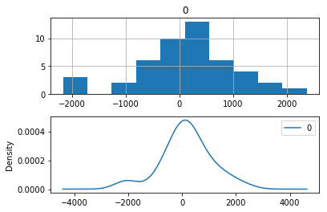

```python
# summarize ARIMA forecast residuals
from pandas import Series
from pandas import DataFrame
from statsmodels.tsa.arima_model import ARIMA
from matplotlib import pyplot

# create a differenced series
def difference(dataset, interval=1):
	diff = list()
	for i in range(interval, len(dataset)):
		value = dataset[i] - dataset[i - interval]
		diff.append(value)
	return diff

# invert differenced value
def inverse_difference(history, yhat, interval=1):
	return yhat + history[-interval]

# load data
series = Series.from_csv('dataset.csv')
# prepare data
X = series.values
X = X.astype('float32')
train_size = int(len(X) * 0.50)
train, test = X[0:train_size], X[train_size:]
# walk-forward validation
history = [x for x in train]
predictions = list()
for i in range(len(test)):
	# difference data
	months_in_year = 12
	diff = difference(history, months_in_year)
	# predict
	model = ARIMA(diff, order=(0,0,1))
	model_fit = model.fit(trend='nc', disp=0)
	yhat = model_fit.forecast()[0]
	yhat = inverse_difference(history, yhat, months_in_year)
	predictions.append(yhat)
	# observation
	obs = test[i]
	history.append(obs)
# errors
residuals = [test[i]-predictions[i] for i in range(len(test))]
residuals = DataFrame(residuals)
print(residuals.describe())
# plot
pyplot.figure()
pyplot.subplot(211)
residuals.hist(ax=pyplot.gca())
pyplot.subplot(212)
residuals.plot(kind='kde', ax=pyplot.gca())
pyplot.show()
```

Distribution has a right shift and that the mean is non-zero at 165.904. The distribution of residual errors suggest a Gaussian-like distribution with a bumpy left tail, providing further evidence that perhaps a power transform might be worth exploring.

```
                 0
count    47.000000
mean    165.904738
std     934.696197
min   -2164.247449
25%    -289.651758
50%     191.759548
75%     732.992187
max    2367.304748
```

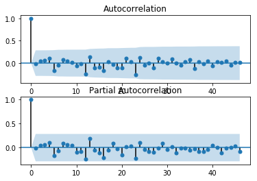

```python
# ACF and PACF plots of residual errors of bias corrected forecasts
from pandas import Series
from pandas import DataFrame
from statsmodels.tsa.arima_model import ARIMA
from matplotlib import pyplot
from statsmodels.graphics.tsaplots import plot_acf
from statsmodels.graphics.tsaplots import plot_pacf

# create a differenced series
def difference(dataset, interval=1):
	diff = list()
	for i in range(interval, len(dataset)):
		value = dataset[i] - dataset[i - interval]
		diff.append(value)
	return diff

# invert differenced value
def inverse_difference(history, yhat, interval=1):
	return yhat + history[-interval]

# load data
series = Series.from_csv('dataset.csv')
# prepare data
X = series.values
X = X.astype('float32')
train_size = int(len(X) * 0.50)
train, test = X[0:train_size], X[train_size:]
# walk-forward validation
history = [x for x in train]
predictions = list()
for i in range(len(test)):
	# difference data
	months_in_year = 12
	diff = difference(history, months_in_year)
	# predict
	model = ARIMA(diff, order=(0,0,1))
	model_fit = model.fit(trend='nc', disp=0)
	yhat = model_fit.forecast()[0]
	yhat = inverse_difference(history, yhat, months_in_year)
	predictions.append(yhat)
	# observation
	obs = test[i]
	history.append(obs)
# errors
residuals = [test[i]-predictions[i] for i in range(len(test))]
residuals = DataFrame(residuals)
print(residuals.describe())
# plot
pyplot.figure()
pyplot.subplot(211)
plot_acf(residuals, ax=pyplot.gca())
pyplot.subplot(212)
plot_pacf(residuals, ax=pyplot.gca())
pyplot.show()
```

The results suggest that what little autocorrelation is present in the time series has been captured by the model.